# P1 : Test a Perpetual Phenomenon

## Background Information

In a Stroop task, participants are presented with a list of words, with each word displayed in a color of ink. The participant’s task is to say out loud the color of the ink in which the word is printed. The task has two conditions: a congruent words condition, and an incongruent words condition. In the congruent words condition, the words being displayed are color words whose names match the colors in which they are printed: for example RED, BLUE. In the incongruent words condition, the words displayed are color words whose names do not match the colors in which they are printed: for example PURPLE, ORANGE. In each case, we measure the time it takes to name the ink colors in equally-sized lists. Each participant will go through and record a time from each condition.

### Question 1 : What is out independent variable? What is our dependent variable ?

In the Stroop task the independent variable is the configuration of the word, ie, color, word, because it is the modifiable parameter. The dependent variable is the measurable time that subject takes to react to spell the Word, ie, the reaction time.

### Question 2 :What is an appropriate set of hypotheses for this task? What kind of statistical test do you expect to perform? Justify your choices.

*Hypothesis*

**i. $H_0$:** The average time of the participants to say the congruent words is not significantly different from the average time it takes the participants to say the incongruent words. In other words, the average time is taken to name the color of the words its the same for both, congruent and incongruent, and it is not significantly different. **i.e** $\mu_i$ = $\mu_c$

**ii. $H_A$:** The averages times of population it takes to name the ink colors is a significant difference between the incongruents words and congruent words. **i.e** $\mu_i$ ≠ $\mu_c$

**where,**

- $H_0$ : Null Hypothesis
- $H_A$ : Alternate Hypothesis
- $\mu_i$ : Population mean for Incongruent condition
- $\mu_c$ : Population mean for Congruent condition

### Question 3 : Report some descriptive statistics regarding this dataset. Include at least one measure of central tendency and at least one measure of variability.

*Descriptive Statistics*

|  | Congruent | Incongruent | Difference(I-C) |
| --- | --- | --- | --- |
| Mean | 14.051 | 22.015 | 7.96 |
| Median | 14.357 | 21.018 | 7.67 |
| Standard Deviation | 3.559 | 4.797 | 4.865 |

```python
import pandas as pd
import statistics

# Read the csv data set
dframe=pd.read_csv("stroopdata.csv")

print ("Mean of Congruent :", statistics.mean(dframe["Congruent"]))
print ("Median of Congruent :" ,  statistics.median(dframe["Congruent"]))
```

```
Mean of Congruent : 14.051125
Median of Congruent : 14.3565
```

```python
print ("Mean of Incongruent :", statistics.mean(dframe["Incongruent"]))
print ("Median of Incongruent :", statistics.median(dframe["Incongruent"]))
```

```
Mean of Incongruent : 22.0159166667
Median of Incongruent : 21.0175
```

```python
print ("Standar Deviation of Congruent: ", statistics.stdev(dframe["Congruent"]))
```

```
Standar Deviation of Congruent:  3.5593579576451955
```

```python
print ("Standar Deviation of Incongruent: ", statistics.stdev(dframe["Incongruent"]))
```

```
Standar Deviation of Incongruent:  4.797057122469138
```

```python
print ("Point estimate :", statistics.mean(dframe["Incongruent"]-dframe["Congruent"]))
```

```
Point estimate : 7.96479166667
```

### Question 4: Provide one or two visualizations that show the distribution of the sample data. Write one or two sentences noting what you observe about the plot or plots.

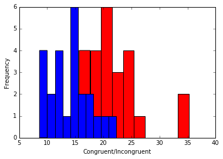

```python
import matplotlib.pyplot as plt
plt.hist(dframe["Incongruent"],color="red")
plt.hist(dframe["Congruent"],color="blue")
plt.xlabel("Congruent/Incongruent")
plt.ylabel("Frequency")
```

The incongruent population's values are mostly higher than the congruence population's values, this suggests when the words do not match the color, takes longer to give the answer.

### Question 5 :Now, perform the statistical test and report your results. What is your confidence level and your critical statistic value? Do you reject the null hypothesis or fail to reject it? Come to a conclusion in terms of the experiment task. Did the results match up with your expectations?

```python
from scipy import stats
n = 24
df = 23                                                  #Degree of freedom Df= n-1 =23

st_dev = (dframe["Incongruent"]-dframe["Congruent"]).std()# Calculating Standard deviation.

point_estimate = (dframe["Incongruent"]-dframe["Congruent"]).mean()# Point estimate mean of difference
                                                                   #in populatio = μinc - μcon
st_error = st_dev/sqrt(24)                              # Calculating Standard error. (SEM)

t_statistic = (point_estimate-0)/st_error               # Calculating T-statistic as XD - 0 /(SD / √n )

t_critical= 2.069                                       # Getting the t critical value for 95% CI. df=23

margin_error=t_critical*st_error                        # Calculating the Margin of error

pval = stats.t.sf(np.abs(t_statistic), n-1)*2           # two-sided pvalue = Prob(abs(t)>tt)

upper_bound = point_estimate + margin_error             # 95% Confidence Interval = (PE+margin_Error, PE-margin_Error)
lower_bound = point_estimate - margin_error

print ("Degrees of freedom :", df)
print ('Point Estimate : {:6.3f}'.format(point_estimate))
print ('Standard Error : {:6.3f}'.format( st_error))
print ("T critical value : +-", t_critical)
print ('T-statistic :  {:6.3f}'.format(t_statistic))
print ('What is the P Value for this t : {:6.3e}'.format(pval))
print ("Compute the Margin or error for the 95%")
print ('95% Confidence Interval is : ({:6.3f}, {:6.3f})'.format(lower_bound ,upper_bound))
```

```
Degrees of freedom : 23
Point Estimate :  7.965
Standard Error :  0.993
T critical value : +- 2.069
T-statistic :   8.021
What is the P Value for this t : 4.103e-08
Compute the Margin or error for the 95%
95% Confidence Interval is : ( 5.910, 10.019)
```

3.Effect size measures

```
* Compute Cohen's d
* Compute r2 (coefficient of determination)
```

```python
from statistics import mean, stdev
from math import sqrt
#Compute all in APA Style
#compute Cohend'sD
cohens_d = (mean(dframe["Congruent"]) - mean(dframe["Incongruent"]))/(sqrt((stdev(dframe["Congruent"])**2+ stdev(dframe["Incongruent"])**2)/2))
print("Cohen's D :  {:6.4f}".format(cohens_d))
#compute
r = (t_statistic**2) / ((t_statistic**2) + df)
print('Coefficient of Determination : {:.2f}'. format(r))
```

```
Cohen's D :  -1.8857
Coefficient of Determination : 0.74
```

### Question 6 Optional: What do you think is responsible for the effects observed? Can you think of an alternative or similar task that would result in a similar effect? Some research about the problem will be helpful for thinking about these two questions!

### Conclusions

As the value of t-statistics(8.021) is greater than t-critical(+- 2.069) t fall in the criticall region. P-value is less than alpha level, then we can reject the null in favor of the alternate hypothesis. This mean also that incongruente condition had a significant impact on the test outcome.

The delay is because it's easier to read the word than to identify the color and pronounce. Another similar experiment could be count numbers and words, first written identical words and numbers (two, two), and the second do not match the words and number ( one, one, one). You should say "Three"

### References :

- Spreedsheet https://docs.google.com/spreadsheets/d/1YAEAZ0AG_aAnMf8KoX1P9mmODQ08uHW7tLas_lXBMmU/edit#gid=927079756